# Text Prediction using Stupid Back-off Model

John Goodwin  
6/7/2021

### Problem

Have you ever been frustrated when tediously typing out every word of a text, email, or comment? The predictive text model built for this project can eliminate this frustration by providing word or even sentence suggestions based on a word or phrase.

This presentation will give you:

- An introduction to the Stupid Back-off model used for prediction
- The Shiny application designed around the model

### Model

Stupid Back-off (SBO) models use sequences of words (n-grams) to estimate the probability of an upcoming word. During training, there are two parameters that can influence model accuracy and complexity:

- Lambda: the penalization parameter
- N: the size of the n-grams used for estimation

A grid search found the following:

- Lambda had relatively little impact on accuracy but almost no impact on fit time
- N values above 3 lead to less accurate models, but with significant time penalties (next slide)
- Training on more data had a more significant impact on model accuracy than either tuning parameter

### N-gram Size Impact on Accuracy and Fit Time

Model performance deteriorates while model fit time ballooned as n-gram size increased

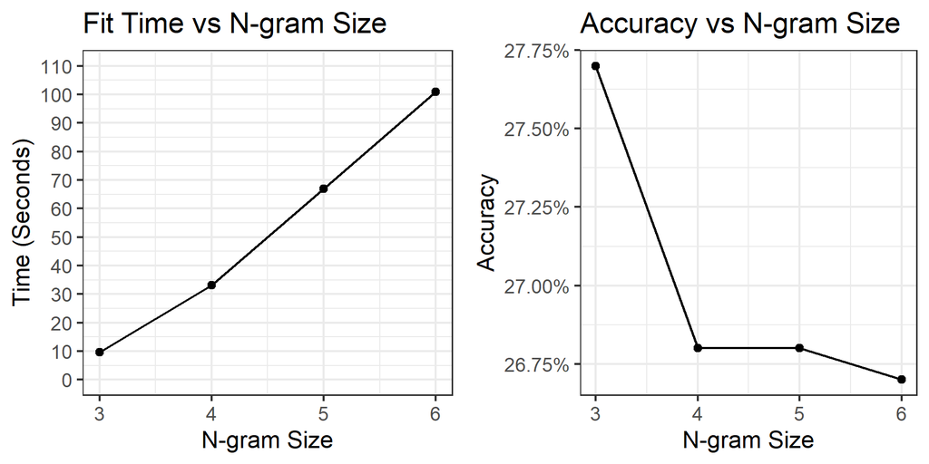

Results based on a 30K row sample of the training data.

### Shiny Application

The final model was packaged up in a [Shiny application](https://wiscodisco5.shinyapps.io/swiftkey-nlp-project/) that offers two main functions:

- Next Word prediction – suggests 3 words based off a word or phrase
- “Babbles” – sentence completion based off a word or phrase

Predictions can be generated by:

1. Providing text to the `Text Input` box
2. Clicking `Run` to generate predictions

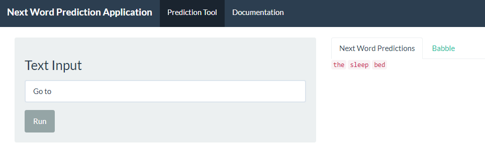

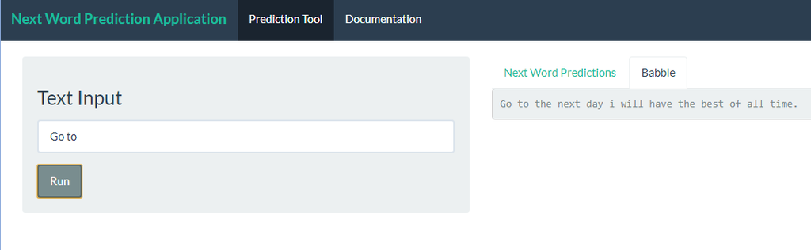